# Stat 461 HW2

Roshan Poduval

9/30/2020

1. Question 1
- $E[e^x] = \int_{-\infty}^{\infty} e^x * \frac{1}{.5\sqrt{2\pi}} * e^{-\frac{1}{2}(\frac{x-.8}{.5})^2} dx \approx 2.52$

  $Var(e^x) = \int_{-\infty}^{\infty} (e^x)^2 * \frac{1}{.5\sqrt{2\pi}} * e^{-\frac{1}{2}(\frac{x-.8}{.5})^2} dx \approx 8.17 - (2.52)^2 = 1.82$

```r
set.seed(123)
x = rnorm(500, mean=.8, sd=.05)
cat("Mean for sample of simple net returns is", mean(exp(x)), "\n")
```

```
## Mean for sample of simple net returns is 2.23203
```

```r
cat("Variance for sample of simple net retruns is", sd(exp(x)), "\n")
```

```
## Variance for sample of simple net retruns is 0.1088502
```

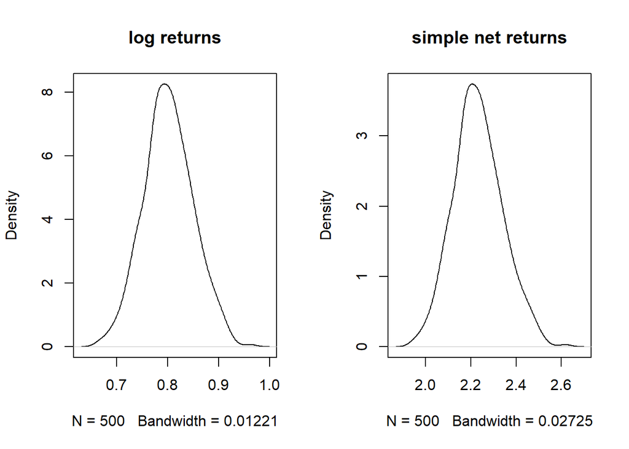

```r
par(mfrow=c(1,2))
plot(density(x), main = "log returns")#hist(x, main="log returns", col="red")
plot(density(exp(x)), main = "simple net returns")#hist(exp(x), main="simple returns", col = "blue")
```

+ The plot of log returns is much less spread out compared to the simple returns. They both look normally distributed.

2. Question 2
- $P(p_{20}>16)=P(sum(r_t) > 4)\approx0.3446$ where $sum(r_t)$~$_{iid}N(.1*20, .5^2*20)=N(2, \sqrt{5}^2)$

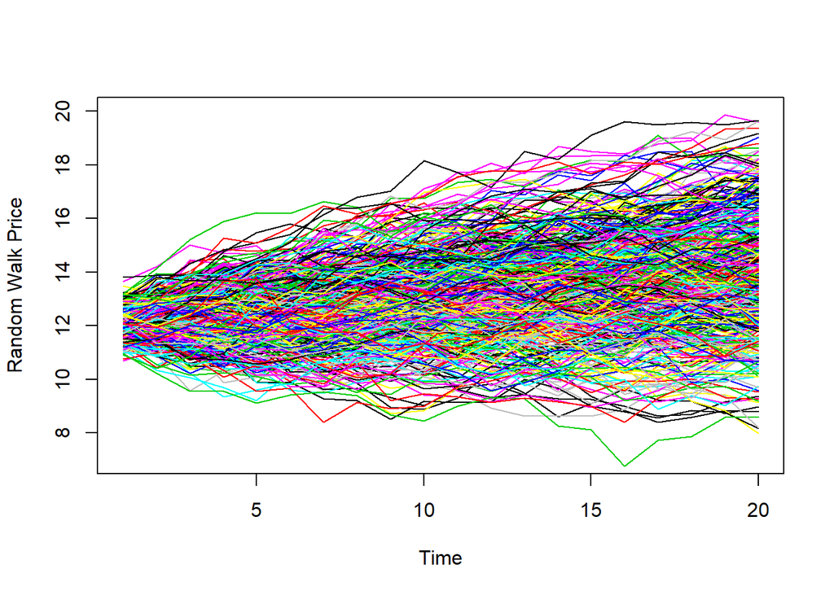

```r
set.seed(123)
p0 = 12
T = 20
sim=500
rt = rnorm(T*sim, mean=.1, sd=.5)
dim(rt) = c(T, sim) # change rt into a T*sim matrix layout
pt = p0 + apply(rt, 2, cumsum) # compute cumulative sums for each column (dimension 2)

x = 1:T
plot(x, pt[,1], xlab="Time", ylab="Random Walk Price", type='l', ylim=c(7,20))
for (i in 2:sim) {
  lines(x, pt[,i], col=i)
}
```

```r
cat("The number of walks with a final price > 16 is", sum(pt[20,]>16), "\n")
```

```
## The number of walks with a final price > 16 is 88
```

```r
cat("Or", sum(pt[20,]>16)/sim, "%", "\n")
```

```
## Or 0.176 %
```

- The number of terminal values from all 500 simulated walks that were greater than 16 was 88. This is about half as many as I would expect based on my answer to part a.
3. Question 3

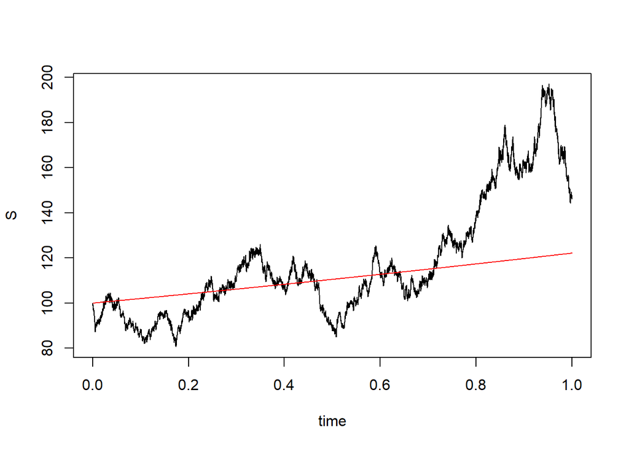

```r
set.seed(1234)
mu = .2
sig = .5
T = 1
S0 = 100
n = 10000
dt = T/n
t = seq(0, T, by=dt)
R = mu*dt + sig*rnorm(n, mean=0, sd=sqrt(dt))
S = c(S0, rep(0,n))
#S = S0 + cumsum(R)
for (i in 1:n) {
  S[i+1] = S[i]*R[i] + S[i]
}
plot(t, S, type="l", xlab="time")
lines(t, c(S0*exp(mu*t)), col="red") #abline(lm(S~c(1:10000)))
```

```r
set.seed(123)
mu = .2
sig = .5
sim = 500
T = 1
S0 = 100
n = 10000
dt = T/n
t = seq(0, T, by=dt)
R = mu*dt + sig*rnorm(n*sim, mean=0, sd=sqrt(dt))
dim(R) = c(n, sim)
S = matrix(rep(0, (n+1)*sim), n+1, sim)
S[1,] = rep(S0, sim)
for (j in 1:sim) {
  for (i in 1:n) {
    S[i+1,j] = S[i,j]*R[i,j]+S[i,j]
  }
}
cat("There are", sum(S[(.8/dt),]>120), "simulated values for S at time 0.8 that are greater than 120\n")
```

```
## There are 188 simulated values for S at time 0.8 that are greater than 120
```

```r
pnorm(log(120/100), mean=0.06, sd=sqrt(0.2), lower.tail = F)
```

```
## [1] 0.392227
```

- $\Delta W_t$~$_{iid}N(0,\Delta t)$

  $\Delta t = .0001$

  $\sum_1^{8000}{\Delta W_t}$~$N(0*1000,\sqrt{\Delta t *8000}^2=N(0,\sqrt{.8}^2)$

  $S_{.8}=100+.2*\Delta t*8000+.5\sum_1^{8000}\Delta W_t=100.16+.5\sum_1^{8000}\Delta W_t$

  $.5\sum_1^{8000}\Delta W_t$~$N(0, \sqrt{.5^2*.8}^2)$

  $S_{.8}$~$N(100.16, \sqrt{.5^2*.8}^2)$

  $P(S_{.8}>120)$ is very small for the above theoretical distribution. For some reason 188/500 (37.6% of simulated values at time 0.8) were above 120.
4. Question 4

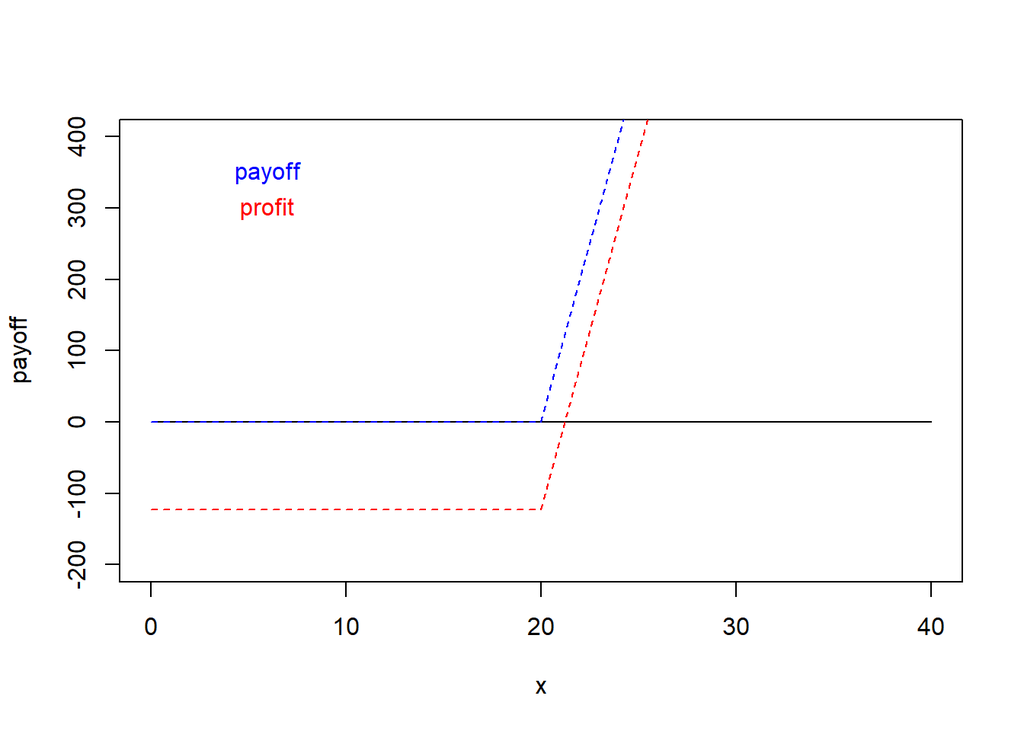

```r
x = seq(0,4000)/100.00
premium = 100
p0 = 20
y = integer(0)
payoff = integer(0)
for (price in x) {
  payoff = append(payoff, max(c((price*100 - p0*100), 0)))
}
y = payoff - (exp(0.12/4)*premium)
plot(x, payoff, type="n", lty=1, lwd=1, col="blue", ylim=c(-200,400))
lines(x, replicate(length(x), 0))
lines(x, payoff, lty=2, lwd=1, col="blue")
lines(x, (y-p0), lty=2, lwd=1, col="red")
text(6, 350, labels="payoff", col="blue")
text(6, 300, labels="profit", col="red")
```

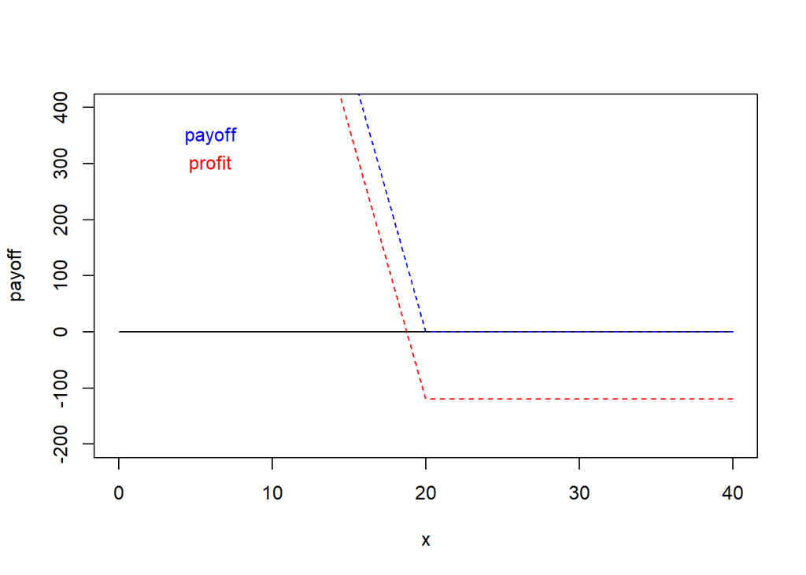

```r
x = seq(0,4000)/100.00
premium = 100
p0 = 20
y = integer(0)
payoff = integer(0)
for (price in x) {
  payoff = append(payoff, max(c((exp(-0.12/4)*(p0*100 - price*100)), 0)))
}
y = payoff - premium
plot(x, payoff, type="n", lty=1, lwd=1, col="blue", ylim=c(-200,400))
lines(x, replicate(length(x), 0))
lines(x, payoff, lty=2, lwd=1, col="blue")
lines(x, (y-p0), lty=2, lwd=1, col="red")
text(6, 350, labels="payoff", col="blue")
text(6, 300, labels="profit", col="red")
```